# INTRODUCTION TO MACHINE LEARNING ASSIGNMENT

## ROBERTO BERROCAL

#### BUSINESS CONTEXT

This dataset can be used to predict the chronic kidney disease, and it can be collected from the hospital nearly 2 months of period.

Data dictionary:

| **Variable Short Name** | **Long Name (description)** |
| --- | --- |
| age | Age |
| bp | Blood Pressure |
| sg | Specific Gravity |
| al | Albumin |
| su | Sugar |
| rbc | Red Blood Cells |
| pc | Pus Cell |
| pcc | Pus Cell Clumps |
| ba | Bacteria |
| bgr | Blood Glucose Random |
| bu | Blood Urea |
| sc | Serum Creatinine |
| sod | Sodium |
| pot | Potassium |
| hemo | Hemoglobin |
| pcv | Packed Cell Volume |
| wbcc | White Blood Cell Count |
| rbcc | Red Blood Cells Count |
| htn | Hypertension |
| dm | Diabetes Mellitus |
| cad | Coronary Artery Disease |
| appet | Appetite |
| pe | Pedal Edema |
| ane | Anemia |
| class | Class (CKD or NOT CKD) |

The aim of the dataset is to predict Chronic Kidney Disease (CKD) accurately based on some features.

#### IMPORTING LIBRARIES

```python
import pandas as pd
import numpy as np
import matplotlib.pyplot as plt
import seaborn as sns
from sklearn.preprocessing import LabelEncoder
from sklearn.preprocessing import StandardScaler
from sklearn.model_selection import train_test_split
from sklearn.metrics import accuracy_score, confusion_matrix, classification_report
from sklearn.ensemble import RandomForestClassifier
from sklearn.linear_model import LogisticRegression
from sklearn.svm import SVC
from sklearn.neighbors import KNeighborsClassifier
from sklearn.tree import DecisionTreeClassifier
from sklearn.model_selection import cross_val_score


import warnings
warnings.filterwarnings('ignore')
```

#### DATASET EXPLORING

```python
df = pd.read_csv('kidney_disease.csv')
```

```python
df.head()
```

|  | id | age | bp | sg | al | su | rbc | pc | pcc | ba | ... | pcv | wc | rc | htn | dm | cad | appet | pe | ane | classification |
| --- | --- | --- | --- | --- | --- | --- | --- | --- | --- | --- | --- | --- | --- | --- | --- | --- | --- | --- | --- | --- | --- |
| 0 | 0 | 48.0 | 80.0 | 1.020 | 1.0 | 0.0 | NaN | normal | notpresent | notpresent | ... | 44 | 7800 | 5.2 | yes | yes | no | good | no | no | ckd |
| 1 | 1 | 7.0 | 50.0 | 1.020 | 4.0 | 0.0 | NaN | normal | notpresent | notpresent | ... | 38 | 6000 | NaN | no | no | no | good | no | no | ckd |
| 2 | 2 | 62.0 | 80.0 | 1.010 | 2.0 | 3.0 | normal | normal | notpresent | notpresent | ... | 31 | 7500 | NaN | no | yes | no | poor | no | yes | ckd |
| 3 | 3 | 48.0 | 70.0 | 1.005 | 4.0 | 0.0 | normal | abnormal | present | notpresent | ... | 32 | 6700 | 3.9 | yes | no | no | poor | yes | yes | ckd |
| 4 | 4 | 51.0 | 80.0 | 1.010 | 2.0 | 0.0 | normal | normal | notpresent | notpresent | ... | 35 | 7300 | 4.6 | no | no | no | good | no | no | ckd |

5 rows × 26 columns

```python
df.shape
```

```
(400, 26)
```

```python
# I will drop the id column
df.drop('id', axis = 1, inplace = True)
```

```python
# columns are not so easy to handle with their current name, i will change the name of the columns
df.columns = ['Age', 'BloodPressure', 'SpecificGravity', 'Albumin', 'Sugar', 'RedBloodCells', 'PusCell',
 'PusCellClumps', 'Bacteria', 'BloodGlucoseRandom', 'BloodUrea', 'SerumCreatinine', 'Sodium',
 'Potassium', 'Haemoglobin', 'PackedCellVolume', 'WhiteBloodCellCount', 'RedBloodCellCount',
 'Hypertension', 'DiabetesMellitus', 'CoronaryArteryDisease', 'Appetite', 'PedaEdema',
 'Aanemia', 'Class']
```

```python
df.head()
```

|  | Age | BloodPressure | SpecificGravity | Albumin | Sugar | RedBloodCells | PusCell | PusCellClumps | Bacteria | BloodGlucoseRandom | ... | PackedCellVolume | WhiteBloodCellCount | RedBloodCellCount | Hypertension | DiabetesMellitus | CoronaryArteryDisease | Appetite | PedaEdema | Aanemia | Class |
| --- | --- | --- | --- | --- | --- | --- | --- | --- | --- | --- | --- | --- | --- | --- | --- | --- | --- | --- | --- | --- | --- |
| 0 | 48.0 | 80.0 | 1.020 | 1.0 | 0.0 | NaN | normal | notpresent | notpresent | 121.0 | ... | 44 | 7800 | 5.2 | yes | yes | no | good | no | no | ckd |
| 1 | 7.0 | 50.0 | 1.020 | 4.0 | 0.0 | NaN | normal | notpresent | notpresent | NaN | ... | 38 | 6000 | NaN | no | no | no | good | no | no | ckd |
| 2 | 62.0 | 80.0 | 1.010 | 2.0 | 3.0 | normal | normal | notpresent | notpresent | 423.0 | ... | 31 | 7500 | NaN | no | yes | no | poor | no | yes | ckd |
| 3 | 48.0 | 70.0 | 1.005 | 4.0 | 0.0 | normal | abnormal | present | notpresent | 117.0 | ... | 32 | 6700 | 3.9 | yes | no | no | poor | yes | yes | ckd |
| 4 | 51.0 | 80.0 | 1.010 | 2.0 | 0.0 | normal | normal | notpresent | notpresent | 106.0 | ... | 35 | 7300 | 4.6 | no | no | no | good | no | no | ckd |

5 rows × 25 columns

```python
df.info()
```

```
<class 'pandas.core.frame.DataFrame'>
RangeIndex: 400 entries, 0 to 399
Data columns (total 25 columns):
 #   Column                 Non-Null Count  Dtype
---  ------                 --------------  -----
 0   Age                    391 non-null    float64
 1   BloodPressure          388 non-null    float64
 2   SpecificGravity        353 non-null    float64
 3   Albumin                354 non-null    float64
 4   Sugar                  351 non-null    float64
 5   RedBloodCells          248 non-null    object
 6   PusCell                335 non-null    object
 7   PusCellClumps          396 non-null    object
 8   Bacteria               396 non-null    object
 9   BloodGlucoseRandom     356 non-null    float64
```

[output cut: 17 more lines]

#### DATA CLEANING

FIRST INSIGHTS: This 3 columns, are labeled as objects but they are numerical

- PackedCellVolume
- WhiteBloodCellCount
- RedBloodCellCount

We need to convert them to numeric (integer or float)

```python
# get null values from all columns
df.isnull().sum().sort_values(ascending = False)
```

```
RedBloodCells            152
RedBloodCellCount        130
WhiteBloodCellCount      105
Potassium                 88
Sodium                    87
PackedCellVolume          70
PusCell                   65
Haemoglobin               52
Sugar                     49
SpecificGravity           47
Albumin                   46
BloodGlucoseRandom        44
BloodUrea                 19
SerumCreatinine           17
BloodPressure             12
Age                        9
Bacteria                   4
PusCellClumps              4
Hypertension               2
DiabetesMellitus           2
CoronaryArteryDisease      2
Appetite                   1
PedaEdema                  1
Aanemia                    1
Class                      0
dtype: int64
```

```python
# convert the columns to numeric
df['PackedCellVolume'] = pd.to_numeric(df['PackedCellVolume'], errors='coerce')
df['WhiteBloodCellCount'] = pd.to_numeric(df['WhiteBloodCellCount'], errors='coerce')
df['RedBloodCellCount'] = pd.to_numeric(df['RedBloodCellCount'], errors='coerce')
```

```python
# separating numerical and categorical columns
categorical_cols = [col for col in df.columns if df[col].dtype == 'object']
numerical_cols = [col for col in df.columns if df[col].dtype != 'object']
```

```python
print('Categorical Columns:', categorical_cols)

print('Numerical Columns:', numerical_cols)
```

```
Categorical Columns: ['RedBloodCells', 'PusCell', 'PusCellClumps', 'Bacteria', 'Hypertension', 'DiabetesMellitus', 'CoronaryArteryDisease', 'Appetite', 'PedaEdema', 'Aanemia', 'Class']
Numerical Columns: ['Age', 'BloodPressure', 'SpecificGravity', 'Albumin', 'Sugar', 'BloodGlucoseRandom', 'BloodUrea', 'SerumCreatinine', 'Sodium', 'Potassium', 'Haemoglobin', 'PackedCellVolume', 'WhiteBloodCellCount', 'RedBloodCellCount']
```

```python
# I will look for unique values in the categorical features
for i in categorical_cols:
    print(f"{i} column: {df[i].unique()}")
```

```
RedBloodCells column: [nan 'normal' 'abnormal']
PusCell column: ['normal' 'abnormal' nan]
PusCellClumps column: ['notpresent' 'present' nan]
Bacteria column: ['notpresent' 'present' nan]
Hypertension column: ['yes' 'no' nan]
DiabetesMellitus column: ['yes' 'no' ' yes' '\tno' '\tyes' nan]
CoronaryArteryDisease column: ['no' 'yes' '\tno' nan]
Appetite column: ['good' 'poor' nan]
PedaEdema column: ['no' 'yes' nan]
Aanemia column: ['no' 'yes' nan]
Class column: ['ckd' 'ckd\t' 'notckd']
```

There are some columms that have not curated values, like "\tno" and "\tyes". We need to clean these columns:

- DiabetesMellitus
- CoronaryArteryDisease
- Class

After cleaning those values in that 3 columns, I will convert "Class" to a 1 and 0 values.

```python
df['DiabetesMellitus'].replace(to_replace = {'\tno':'no','\tyes':'yes',' yes':'yes'},inplace=True)

df['CoronaryArteryDisease'].replace(to_replace = '\tno', value='no', inplace= True)

df['Class'].replace(to_replace = {'ckd\t': 'ckd', 'notckd': 'not ckd'}, inplace=True)
```

```python
# Here I change the categorical values to numerical values (1 for positive and 0 for negative)
df['Class'] = df['Class'].map({'ckd': 0, 'not ckd': 1})

df['Class'] = pd.to_numeric(df['Class'], errors='coerce')
```

```python
# checking for values one more time to make sure we have curated them
for i in categorical_cols:
    print(f"{i} column: {df[i].unique()}")
```

```
RedBloodCells column: [nan 'normal' 'abnormal']
PusCell column: ['normal' 'abnormal' nan]
PusCellClumps column: ['notpresent' 'present' nan]
Bacteria column: ['notpresent' 'present' nan]
Hypertension column: ['yes' 'no' nan]
DiabetesMellitus column: ['yes' 'no' nan]
CoronaryArteryDisease column: ['no' 'yes' nan]
Appetite column: ['good' 'poor' nan]
PedaEdema column: ['no' 'yes' nan]
Aanemia column: ['no' 'yes' nan]
Class column: [0 1]
```

#### DATA VISUALIZATION

```python
num_cols = 3
num_rows = (len(numerical_cols) + num_cols - 1) // num_cols
num_rows
```

```
5
```

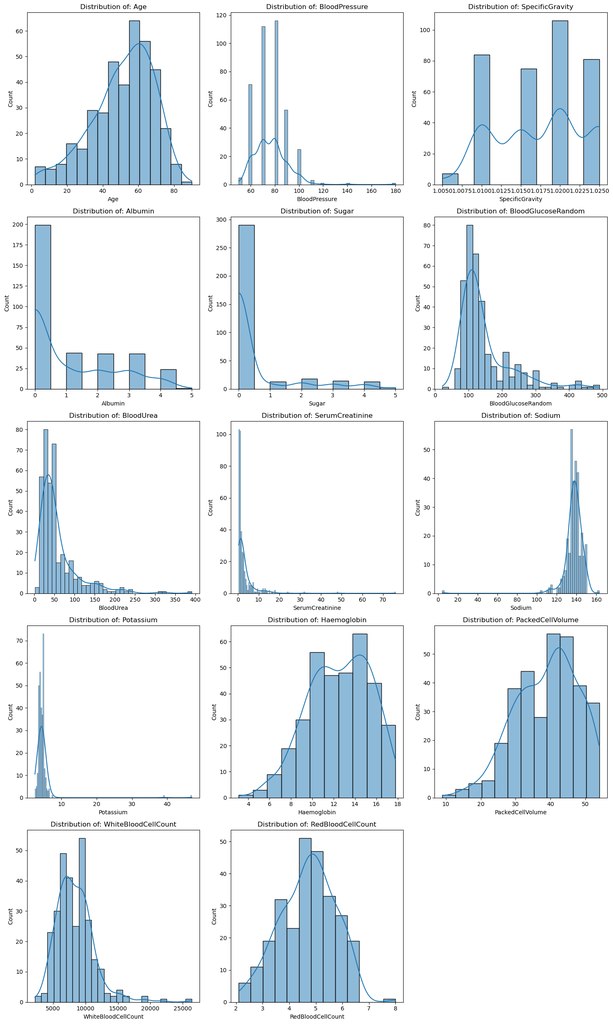

```python
# Here I create a histogram for the numerical columns
# To have a better visualization, I define 3 columns and the number of rows is calculated automatically
num_cols = 3
num_rows = (len(numerical_cols) + num_cols - 1) // num_cols

plt.figure(figsize=(15, 25))

for i, col in enumerate(numerical_cols):
    plt.subplot(num_rows, num_cols, i + 1)
    sns.histplot(df[col], kde=True)
    plt.title(f'Distribution of: {col}')

plt.tight_layout()
plt.show()
```

INSIGHTS:

Blood Pressure: We can see some peaks around 70, 80 and 90. This could be due to the nature of the sampling. Also, there are some higher values above 125 that can be treated as outliers or clinical cases.

Specific Gravity: This feature has a bimodal distribution. It can suggest the existence of two subgroups within the data.

Blood Urea and Serum Creatinine: Both variables are strongly right skewed. These indicators can vary in patients with kidney disease. Some high values can be considered as outliers.

Sodium and Potassium: Both of these variables seem more concentrated with tighter distributions. Sodium shows values around 130-150. Potassium has a right skewed behavior and a narrower distribution

Hemoglobin and Packed Cell Volume: Both of them seem to have a normal distribution with slight skewness to the left. These are common indicators in blood tests for patients with CKD

With Blood Cell Count and Red Blood Cell Count: These features have a very close to normal distribution behavior but have some high values on the right.

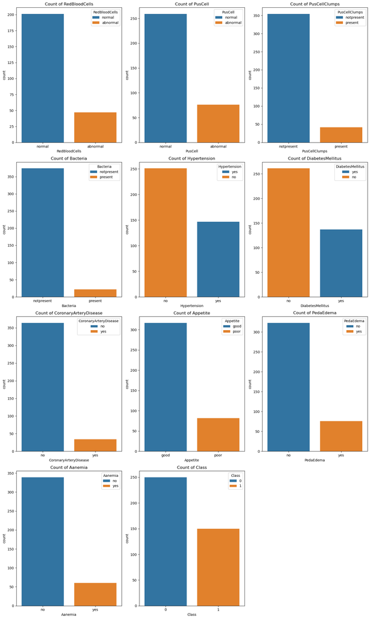

```python
# Here I create the countplot for the categorical columns
num_cols = 3
num_rows = (len(categorical_cols) + num_cols - 1) // num_cols

plt.figure(figsize=(15, 25))

for i, col in enumerate(categorical_cols):
    plt.subplot(num_rows, num_cols, i + 1)
    sns.countplot(x=df[col], order=df[col].value_counts().index, hue= df[col])
    plt.title(f'Count of {col}')

plt.tight_layout()
plt.show()
```

INSIGHTS:

Red Blood Cells, Pus Cell and Pus Cell Clumps: Most patients have normal values of these three variables but a important number of them show abnormalities, leading to potential renal issues.

Bacteria: The majority do not have bacteria present. Only a small part of them show positive results.

Coronary Artery Disease: Few patients have coronary artery disease.

Appetite: Most patients report good appetite, although there is a small group with bad appetite with is a sign of disease presence.

```python
df.info()
```

```
<class 'pandas.core.frame.DataFrame'>
RangeIndex: 400 entries, 0 to 399
Data columns (total 25 columns):
 #   Column                 Non-Null Count  Dtype
---  ------                 --------------  -----
 0   Age                    391 non-null    float64
 1   BloodPressure          388 non-null    float64
 2   SpecificGravity        353 non-null    float64
 3   Albumin                354 non-null    float64
 4   Sugar                  351 non-null    float64
 5   RedBloodCells          248 non-null    object
 6   PusCell                335 non-null    object
 7   PusCellClumps          396 non-null    object
 8   Bacteria               396 non-null    object
 9   BloodGlucoseRandom     356 non-null    float64
```

[output cut: 17 more lines]

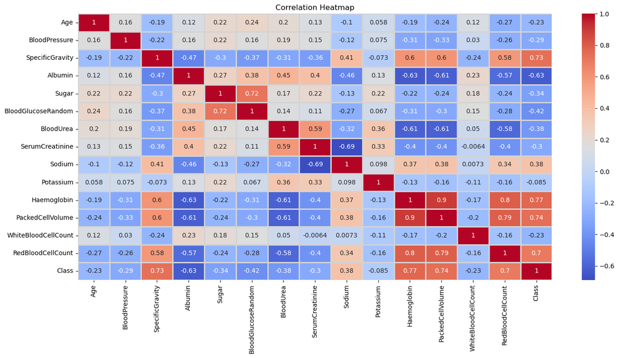

```python
# Filtrar solo columnas numéricas del DataFrame
df_numeric = df.select_dtypes(include=['float64', 'int64'])

# Crear el heatmap de la correlación
plt.figure(figsize=(15, 8))
sns.heatmap(df_numeric.corr(), annot=True, linewidths=2, linecolor='lightgrey', cmap='coolwarm')
plt.title('Correlation Heatmap')

plt.tight_layout()
plt.show()
```

INSIGHTS:

Haemoglobin and PackedCellVolume have a very strong positive correlation (0.9). It is likely that they include redundant information. Blood Urea and Serum Creatinine are also moderately correlated (0.59), suggesting a relationship between these two variables.

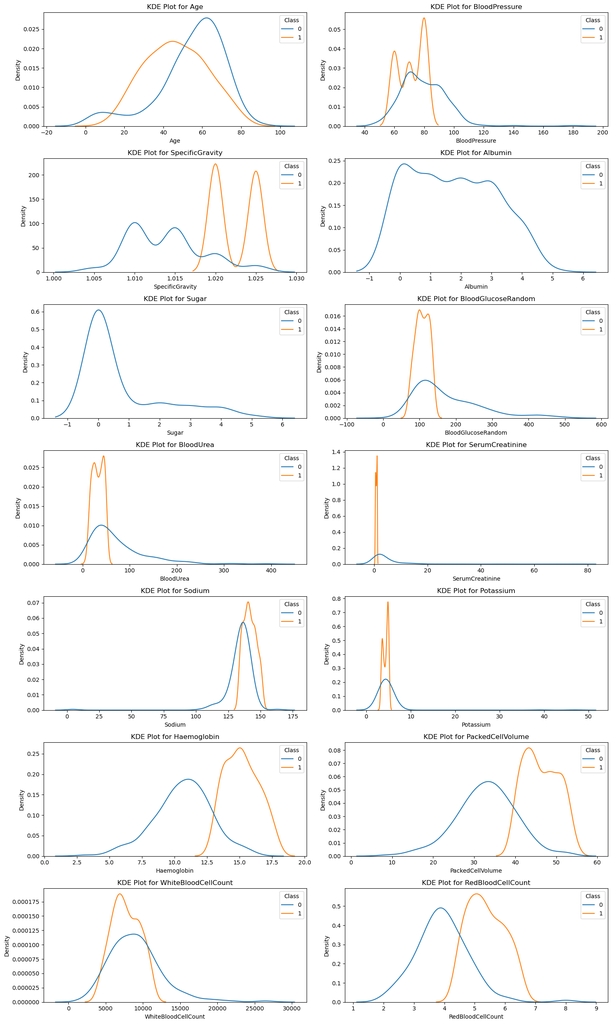

```python
# Here I create the KDE plot for the numerical columns by class
num_cols = 2
num_rows = (len(numerical_cols) + num_cols - 1) // num_cols

plt.figure(figsize=(15, 25))

for i, col in enumerate(numerical_cols):
    plt.subplot(num_rows, num_cols, i + 1)
    sns.kdeplot(data=df, x=col, hue="Class", common_norm=False)
    plt.title(f'KDE Plot for {col}')

plt.tight_layout()
plt.show()
```

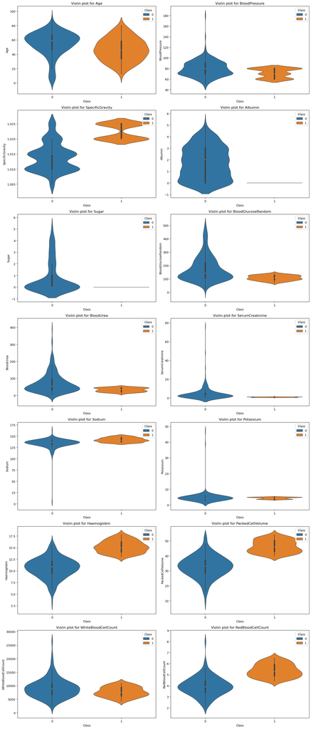

```python
# Here I create the violin plot for the numerical columns by class
num_cols = 2
num_rows = (len(numerical_cols) + num_cols - 1) // num_cols

# Here I make bigger the height of the plot for a better visualization
plt.figure(figsize=(15, 35))

for i, col in enumerate(numerical_cols):
    plt.subplot(num_rows, num_cols, i + 1)
    sns.violinplot(x="Class", y=col, data=df, hue="Class", inner="box", linewidth=1)
    plt.title(f'Violin plot for {col}')

plt.tight_layout()
plt.show()
```

INSIGHTS (for both visuals):

Blood Pressure: Class 1 has a tighter range around 80 mmHg, while class 0 has more spread in the values. We can infer that higher blood pressure is common in patients with CKD.

Specific Gravity: Class 1 is more concentrated around 1020 meanwhile Class 0 shows more spread in the values. This suggest that this variable is a strong indicator of disease.

#### PRE-PROCESSING

```python
df[numerical_cols].isnull().sum().sort_values(ascending=False)
```

```
RedBloodCellCount      131
WhiteBloodCellCount    106
Potassium               88
Sodium                  87
PackedCellVolume        71
Haemoglobin             52
Sugar                   49
SpecificGravity         47
Albumin                 46
BloodGlucoseRandom      44
BloodUrea               19
SerumCreatinine         17
BloodPressure           12
Age                      9
dtype: int64
```

```python
df[categorical_cols].isnull().sum().sort_values(ascending=False)
```

```
RedBloodCells            152
PusCell                   65
PusCellClumps              4
Bacteria                   4
Hypertension               2
DiabetesMellitus           2
CoronaryArteryDisease      2
Appetite                   1
PedaEdema                  1
Aanemia                    1
Class                      0
dtype: int64
```

```python
# Here I define three functions to impute the missing values with the median, mean and mode
def impute_median(feature):
    median = df[feature].median()
    df[feature] = df[feature].fillna(median)

def impute_mean(feature):
    mean = df[feature].mean()
    df[feature] = df[feature].fillna(mean)

def impute_mode(feature):
    mode = df[feature].mode()[0]
    df[feature] = df[feature].fillna(mode)
```

```python
# Impute missing values with mean
for col in numerical_cols:
    impute_mean(col)
```

```python
df[numerical_cols].isnull().sum().sort_values(ascending=False)
```

```
Age                    0
BloodPressure          0
SpecificGravity        0
Albumin                0
Sugar                  0
BloodGlucoseRandom     0
BloodUrea              0
SerumCreatinine        0
Sodium                 0
Potassium              0
Haemoglobin            0
PackedCellVolume       0
WhiteBloodCellCount    0
RedBloodCellCount      0
dtype: int64
```

```python
# Impute missing values with mode
for col in categorical_cols:
    impute_mode(col)
```

```python
df[categorical_cols].isnull().sum().sort_values(ascending=False)
```

```
RedBloodCells            0
PusCell                  0
PusCellClumps            0
Bacteria                 0
Hypertension             0
DiabetesMellitus         0
CoronaryArteryDisease    0
Appetite                 0
PedaEdema                0
Aanemia                  0
Class                    0
dtype: int64
```

#### FEATURE ENGINEERING

```python
# Here I see the unique values of the categorical columns for future encoding
for col in categorical_cols:
    print(f"{col} has {df[col].nunique()} va\n")
```

```
RedBloodCells has 2 va

PusCell has 2 va

PusCellClumps has 2 va

Bacteria has 2 va

Hypertension has 2 va

DiabetesMellitus has 2 va

CoronaryArteryDisease has 2 va

Appetite has 2 va

PedaEdema has 2 va

Aanemia has 2 va

Class has 2 va
```

```python
# here I create an instance of the LabelEncoder
le = LabelEncoder()

# Here I encode the categorical columns with the LabelEncoder
for col in categorical_cols:
    df[col] = le.fit_transform(df[col])
```

```python
# scaler = StandardScaler()

# df[numerical_cols] = scaler.fit_transform(df[numerical_cols])
```

```python
# print the new dataset with the encoded columns
df.head()
```

|  | Age | BloodPressure | SpecificGravity | Albumin | Sugar | RedBloodCells | PusCell | PusCellClumps | Bacteria | BloodGlucoseRandom | ... | PackedCellVolume | WhiteBloodCellCount | RedBloodCellCount | Hypertension | DiabetesMellitus | CoronaryArteryDisease | Appetite | PedaEdema | Aanemia | Class |
| --- | --- | --- | --- | --- | --- | --- | --- | --- | --- | --- | --- | --- | --- | --- | --- | --- | --- | --- | --- | --- | --- |
| 0 | 48.0 | 80.0 | 1.020 | 1.0 | 0.0 | 1 | 1 | 0 | 0 | 121.000000 | ... | 44.0 | 7800.0 | 5.200000 | 1 | 1 | 0 | 0 | 0 | 0 | 0 |
| 1 | 7.0 | 50.0 | 1.020 | 4.0 | 0.0 | 1 | 1 | 0 | 0 | 148.036517 | ... | 38.0 | 6000.0 | 4.707435 | 0 | 0 | 0 | 0 | 0 | 0 | 0 |
| 2 | 62.0 | 80.0 | 1.010 | 2.0 | 3.0 | 1 | 1 | 0 | 0 | 423.000000 | ... | 31.0 | 7500.0 | 4.707435 | 0 | 1 | 0 | 1 | 0 | 1 | 0 |
| 3 | 48.0 | 70.0 | 1.005 | 4.0 | 0.0 | 1 | 0 | 1 | 0 | 117.000000 | ... | 32.0 | 6700.0 | 3.900000 | 1 | 0 | 0 | 1 | 1 | 1 | 0 |
| 4 | 51.0 | 80.0 | 1.010 | 2.0 | 0.0 | 1 | 1 | 0 | 0 | 106.000000 | ... | 35.0 | 7300.0 | 4.600000 | 0 | 0 | 0 | 0 | 0 | 0 | 0 |

5 rows × 25 columns

#### DATASET SPLIT

```python
# dividing the datagrame into X colums and y column
X = df.drop('Class', axis=1)
y = df['Class']
```

```python
# splitting data intp training and test set
X_train, X_test, y_train, y_test = train_test_split(X, y, test_size = 0.30, random_state = 0)
```

#### MACHINE LEARNING MODELS

##### LOGISTIC REGRESSION

```python
# fitting the model
log_class = LogisticRegression(max_iter=1000, random_state=0)
log_class.fit(X_train, y_train)

# calculating the accuracy
log_class_acc = accuracy_score(y_test, log_class.predict(X_test))
# calculating the cross validation score
log_cross_val = cross_val_score(log_class, X_train, y_train, cv=5, scoring='accuracy').mean()
```

```python
# printing the results
print(f"Training Accuracy of Logistic Regression is {accuracy_score(y_train, log_class.predict(X_train))}")
print(f"Validation Accuracy of Logistic Regression is {log_cross_val}")
print(f"Test Accuracy of Logistic Regression is {log_class_acc} \n")
print(f"Confusion Matrix : \n{confusion_matrix(y_test, log_class.predict(X_test))}\n")
print(f"Classification Report :\n {classification_report(y_test, log_class.predict(X_test))}")
```

```
Training Accuracy of Logistic Regression is 0.9964285714285714
Validation Accuracy of Logistic Regression is 0.9535714285714285
Test Accuracy of Logistic Regression is 0.9583333333333334

Confusion Matrix :
[[67  5]
 [ 0 48]]

Classification Report :
               precision    recall  f1-score   support

           0       1.00      0.93      0.96        72
           1       0.91      1.00      0.95        48

    accuracy                           0.96       120
   macro avg       0.95      0.97      0.96       120
weighted avg       0.96      0.96      0.96       120
```

##### K-NEAREST NEIGHBORS

```python
# fitting the model
knn_class = KNeighborsClassifier()
knn_class.fit(X_train, y_train)

# calculating the accuracy
knn_class_acc = accuracy_score(y_test, knn_class.predict(X_test))
# calculating the cross validation score
knn_cross_val = cross_val_score(knn_class, X_train, y_train, cv=5, scoring='accuracy').mean()
```

```python
# printing the results
print(f"Training Accuracy of KNN is {accuracy_score(y_train, knn_class.predict(X_train))}")
print(f"Validation Accuracy of KNN is {knn_cross_val}")
print(f"Test Accuracy of KNN is {knn_class_acc} \n")

print(f"Confusion Matrix :\n{confusion_matrix(y_test, knn_class.predict(X_test))}\n")
print(f"Classification Report :\n {classification_report(y_test, knn_class.predict(X_test))}")
```

```
Training Accuracy of KNN is 0.8214285714285714
Validation Accuracy of KNN is 0.6857142857142857
Test Accuracy of KNN is 0.725

Confusion Matrix :
[[47 25]
 [ 8 40]]

Classification Report :
               precision    recall  f1-score   support

           0       0.85      0.65      0.74        72
           1       0.62      0.83      0.71        48

    accuracy                           0.72       120
   macro avg       0.73      0.74      0.72       120
weighted avg       0.76      0.72      0.73       120
```

##### DECISION TREE

```python
# fitting the model
des_tree_class = DecisionTreeClassifier(random_state=0)
des_tree_class.fit(X_train, y_train)

# calculating the accuracy
des_tree_class_acc = accuracy_score(y_test, des_tree_class.predict(X_test))
# calculating the cross validation score
des_tree_cross_val = cross_val_score(des_tree_class, X_train, y_train, cv=5, scoring='accuracy').mean()
```

```python
# printing the results
print(f"Training Accuracy of Decision Tree Classifier is {accuracy_score(y_train, des_tree_class.predict(X_train))}")
print(f"Validation Accuracy of Decision Tree Classifier is {des_tree_cross_val}")
print(f"Test Accuracy of Decision Tree Classifier is {des_tree_class_acc} \n")

print(f"Confusion Matrix :\n{confusion_matrix(y_test, des_tree_class.predict(X_test))}\n")
print(f"Classification Report :\n {classification_report(y_test, des_tree_class.predict(X_test))}")
```

```
Training Accuracy of Decision Tree Classifier is 1.0
Validation Accuracy of Decision Tree Classifier is 0.9642857142857142
Test Accuracy of Decision Tree Classifier is 0.9333333333333333

Confusion Matrix :
[[67  5]
 [ 3 45]]

Classification Report :
               precision    recall  f1-score   support

           0       0.96      0.93      0.94        72
           1       0.90      0.94      0.92        48

    accuracy                           0.93       120
   macro avg       0.93      0.93      0.93       120
weighted avg       0.93      0.93      0.93       120
```

##### RANDOM FOREST

```python
# fitting the model
ran_for_class = RandomForestClassifier(criterion = 'entropy', max_depth = 11, min_samples_leaf = 2, min_samples_split = 3, n_estimators = 130, random_state=0)
ran_for_class.fit(X_train, y_train)

# calculating the accuracy
ran_for_class_acc = accuracy_score(y_test, ran_for_class.predict(X_test))
# calculating the cross validation score
ran_for_cross_val = cross_val_score(ran_for_class, X_train, y_train, cv=5, scoring='accuracy').mean()
```

```python
# printing the results
print(f"Training Accuracy of Random Forest Classifier is {accuracy_score(y_train, ran_for_class.predict(X_train))}")
print(f"Validation Accuracy of Random Forest Classifier is {ran_for_cross_val}")
print(f"Test Accuracy of Random Forest Classifier is {ran_for_class_acc} \n")

print(f"Confusion Matrix :\n{confusion_matrix(y_test, ran_for_class.predict(X_test))}\n")
print(f"Classification Report :\n {classification_report(y_test, ran_for_class.predict(X_test))}")
```

```
Training Accuracy of Random Forest Classifier is 1.0
Validation Accuracy of Random Forest Classifier is 0.9678571428571429
Test Accuracy of Random Forest Classifier is 0.9666666666666667

Confusion Matrix :
[[72  0]
 [ 4 44]]

Classification Report :
               precision    recall  f1-score   support

           0       0.95      1.00      0.97        72
           1       1.00      0.92      0.96        48

    accuracy                           0.97       120
   macro avg       0.97      0.96      0.96       120
weighted avg       0.97      0.97      0.97       120
```

##### SUPPORT VECTOR CLASIFIER

```python
# fitting the model
svm_class = SVC(kernel='linear', random_state=0)
svm_class.fit(X_train, y_train)

# calculating the accuracy
svm_class_acc = accuracy_score(y_test, svm_class.predict(X_test))
# calculating the cross validation score
svm_cross_val = cross_val_score(svm_class, X_train, y_train, cv=5, scoring='accuracy').mean()
```

```python
# printing the results
print(f"Training Accuracy of SVC is {accuracy_score(y_train, svm_class.predict(X_train))}")
print(f"Validation Accuracy of SVC is {svm_cross_val}")
print(f"Test Accuracy of SVC is {svm_class_acc} \n")

print(f"Confusion Matrix :\n{confusion_matrix(y_test, svm_class.predict(X_test))}\n")
print(f"Classification Report :\n {classification_report(y_test, svm_class.predict(X_test))}")
```

```
Training Accuracy of SVC is 0.9785714285714285
Validation Accuracy of SVC is 0.95
Test Accuracy of SVC is 0.9583333333333334

Confusion Matrix :
[[67  5]
 [ 0 48]]

Classification Report :
               precision    recall  f1-score   support

           0       1.00      0.93      0.96        72
           1       0.91      1.00      0.95        48

    accuracy                           0.96       120
   macro avg       0.95      0.97      0.96       120
weighted avg       0.96      0.96      0.96       120
```

##### GRID SEARCH AND HYPERPARAMETER TUNNING

##### RANDOM FOREST

```python
from sklearn.model_selection import GridSearchCV


param_grid = {
    'n_estimators': [100, 130, 150],
    'max_depth': [10, 11, 12],
    'min_samples_split': [2, 3, 5],
    'min_samples_leaf': [1, 2, 4],
    'criterion': ['gini', 'entropy'],
}

# set the classifier
ran_for_class = RandomForestClassifier(random_state=0)

# set up the grid search with 5-fold cross validation
grid_search = GridSearchCV(estimator=ran_for_class,
                           param_grid=param_grid,
                           cv=5,
                           scoring='accuracy',
                           n_jobs=-1,  # Use all processors
                           verbose=1)

# fit the grid search
grid_search.fit(X_train, y_train)
```

```
Fitting 5 folds for each of 162 candidates, totalling 810 fits
```

```
GridSearchCV(cv=5, estimator=RandomForestClassifier(random_state=0), n_jobs=-1,
             param_grid={'criterion': ['gini', 'entropy'],
                         'max_depth': [10, 11, 12],
                         'min_samples_leaf': [1, 2, 4],
                         'min_samples_split': [2, 3, 5],
                         'n_estimators': [100, 130, 150]},
             scoring='accuracy', verbose=1)
```

```python
# print the best parameters and the best accuracy score
print("Best parameters found: ", grid_search.best_params_)
print("Best cross-validation accuracy: ", grid_search.best_score_)

# use the best model to predict on the test set
best_ran_for_model = grid_search.best_estimator_
y_pred = best_ran_for_model.predict(X_test)

# calculate and print the test accuracy
test_accuracy = accuracy_score(y_test, y_pred)
print(f"Test Accuracy with best Random Forest: {test_accuracy}")
print("\nConfusion Matrix:")
print(confusion_matrix(y_test, y_pred))
print("\nClassification Report:")
print(classification_report(y_test, y_pred))
```

```
Best parameters found:  {'criterion': 'gini', 'max_depth': 10, 'min_samples_leaf': 1, 'min_samples_split': 2, 'n_estimators': 100}
Best cross-validation accuracy:  0.9785714285714286
Test Accuracy with best Random Forest: 1.0

Confusion Matrix:
[[72  0]
 [ 0 48]]

Classification Report:
              precision    recall  f1-score   support

           0       1.00      1.00      1.00        72
           1       1.00      1.00      1.00        48

    accuracy                           1.00       120
   macro avg       1.00      1.00      1.00       120
weighted avg       1.00      1.00      1.00       120
```

```python
# make a dataframe to compare the models
accuracies = pd.DataFrame({
    'Model': ['Logistic Regression', 'KNN', 'Decision Tree', 'Random Forest', 'SVM', 'Best Random Forest'],
    'Validation Accuracy': [log_cross_val, knn_cross_val, des_tree_cross_val, ran_for_cross_val, svm_cross_val, grid_search.best_score_],
    'Test Accuracy': [log_class_acc, knn_class_acc, des_tree_class_acc, ran_for_class_acc, svm_class_acc, test_accuracy]
})

accuracies
```

|  | Model | Validation Accuracy | Test Accuracy |
| --- | --- | --- | --- |
| 0 | Logistic Regression | 0.953571 | 0.958333 |
| 1 | KNN | 0.685714 | 0.725000 |
| 2 | Decision Tree | 0.964286 | 0.933333 |
| 3 | Random Forest | 0.967857 | 0.966667 |
| 4 | SVM | 0.950000 | 0.958333 |
| 5 | Best Random Forest | 0.978571 | 1.000000 |

## FINAL DISCUSSION

I have used the following models to this dataset:

- Logistic Regression
- K-Nearest Neighbors
- Decision Tree
- Random Forest
- Support Vector Machine

The best model was Random Forest because of its accuracy, showed in the table above (0.966667), so it was the model selected for the hyper parameter tunning step.

During the grid search, it optimized some hyperparameters like:

- n_estimators
- max_depth
- min_samples_leaf
- min_samples_split
- criterion

After the hyperparameter tunning, the best random forest model got a validation accuracy of 0.9786.

After evaluating the best model to the test dataset, it obtained 1 of accuracy. The conclusion is that the model generalizes very well to the test data, due to the hyperparameter tunning.

Some strengths of the solution are that almost every model gets a excellent accuracy score, except for the KNN model, concluding that the dataset is good for predictive approaches. Also, the best model (Random Forest) is very robust to overfitting due to its ensemble technique and the validation and accuracy scores suggest that the model is not overfitting.

One of the limitations is that Random Forest models are complex to interpret, especially the parameter selection compared to other models like Logistic Regression. The model is known for being a black box. Data quality is also a limitation because the model’s success relies on both the quality and quantity of the data, that means that unrepresentative features can affect directly to the model performance. Although the model performed perfectly on the test dataset, this could imply a slight overfitting, the suggestion is to gather more rows to test again the model and its performance.

The proposed machine learning pipeline using Random Forest could help with the automation of the prediction of CKD in real time, improving operational efficiency and reducing manual work. Due to its health approach, the predictions can be used to prioritize treatments or critical patients, saying this the model is ready to be deployed.

The most informative features are:

These features have a biological meaning related to the kidney and with health. The high importance of this feature indicates that they are key to the prediction of the chronic kidney disease.

Recommendations:

Increase the size of the dataset, 400 rows seem to be a short size dataset trying to gather more data to test the model should be included.

To improve the interpretability of the model, more advanced techniques like SHAP (Shapley Additive explanations) or LIME (Local interpretable Model agnostic Explanations) can be applied to explain better the features and its importance, making the model more interpretable for stakeholders.